# Capabilité et SPC · Livret de TP sur pièces

CQPM Technicien Qualité TQ6 · 5, 6 et 25 novembre 2026 · AFPI Bourges

Nom : ........................................................ Entreprise : ..........................................

**Le principe :** pendant trois jours, on travaille sur de vraies pièces. On les mesure, on juge si le lot plaît au client, on surveille une production, puis on vérifie si nos instruments méritent notre confiance. Les calculs sont faits par Excel. Votre travail : mesurer avec soin, lire les résultats, décider.

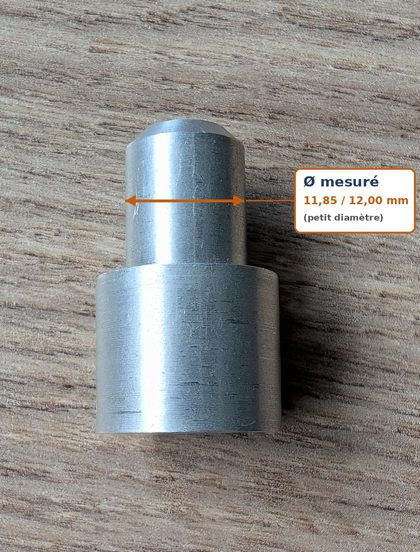

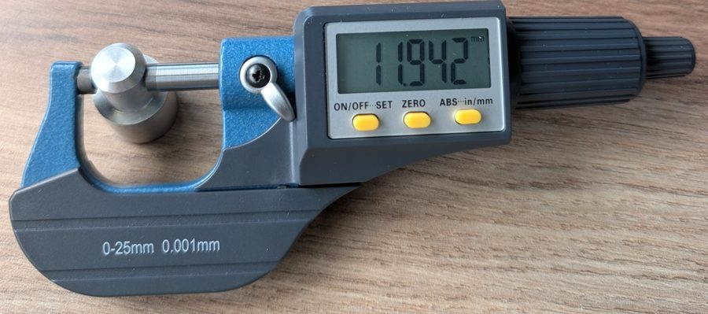

**Nos pièces :** 20 butées tournées. On mesure le **petit diamètre**, tolérance 11,85 / 12,00 mm.  
**Nos instruments :** un pied à coulisse au 1/50 (0,02 mm) et un micromètre numérique 0-25 mm au 0,001 mm.

## Sommaire

| Fiche | Titre | Jour |
| --- | --- | --- |
| A | Flash mesure en aveugle | J1 |
| B | Notre lot de production | J1 |
| C | Trois clients, un seul lot | J1 |
| D | Production simulée et carte X̄/R | J2 |
| M | Mission d'intersession : ma cote critique | J2 à J3 |
| E | Étude R&R : pied à coulisse contre micromètre | J3 |
| F | Plan de maîtrise d'une cote | J3 |
| Q | Évaluation finale | J3 |

## Mots à connaître

| Mot | Ce que ça veut dire, avec mes mots |
| --- | --- |
| Moyenne |  |
| Écart-type |  |
| Tolérance (IT) |  |
| Cp |  |
| Cpk |  |
| Cause commune / cause spéciale |  |
| Limite de contrôle |  |
| Répétabilité |  |
| Reproductibilité |  |

On remplit ce tableau au fil des trois jours, avec ses propres mots.

Capabilité et SPC · CQPM Technicien Qualité TQ6 · Pôle Formation UIMM CVDL · S. Jaubert · Novembre 2026

A

# Flash mesure en aveugle

Jour 1 · 40 min · pied à coulisse puis micromètre

**Objectif :** constater par soi-même ce que donne la mesure d'une même pièce par plusieurs personnes.

## Consignes

1. Mesurez le **petit diamètre** des butées n° 1 à 5, au pied à coulisse.
2. Écrivez chaque valeur sur un post-it, **sans la montrer** ni en parler.
3. Recopiez vos valeurs ci-dessous. Le formateur affiche ensuite les valeurs de tout le groupe.
4. Mesurez ensuite la butée n° 1 au micromètre. Annoncez au formateur vos deux valeurs pour la butée n° 1 (pied à coulisse et micromètre). Il les note au tableau.

## Mes mesures (mm)

| Butée n° | 1 | 2 | 3 | 4 | 5 |
| --- | --- | --- | --- | --- | --- |
| **Pied à coulisse** |  |  |  |  |  |
| **Micromètre** |  |  |  |  |  |

## Les valeurs du groupe pour la butée n° 1

Une valeur par case : celle que chaque stagiaire a lue sur la **butée n° 1**. Pas de moyenne. Dernière colonne : la plus grande valeur moins la plus petite.

| Stagiaire | 1 | 2 | 3 | 4 | 5 | 6 | Écart maxi |
| --- | --- | --- | --- | --- | --- | --- | --- |
| **Pied à coulisse** |  |  |  |  |  |  |  |
| **Micromètre** |  |  |  |  |  |  |  |

## À débattre

1. Quelle est la vraie valeur de cette pièce ?
2. D'où peuvent venir les écarts ? Citez au moins trois causes.
3. La tolérance des butées va de 11,85 à 12,00 mm. Quel instrument choisiriez-vous ? Pourquoi ?

**À retenir :** une mesure n'est jamais la vraie valeur. C'est la vraie valeur plus une erreur de mesure. Nous verrons le 25 novembre comment mesurer cette erreur.

Capabilité et SPC · CQPM Technicien Qualité TQ6 · Pôle Formation UIMM CVDL · S. Jaubert · Novembre 2026

B

# Notre lot de production

Jour 1 · 75 min · micromètre · classeur 1

**Objectif :** mesurer tout le lot, voir la forme de sa variabilité et la décrire avec deux nombres.

## Organisation

**Opérateurs**Mesurent le petit diamètre de leurs butées au micromètre, toujours au même endroit (trait repère), et annoncent la valeur avec ses 3 décimales.

**Secrétaire**Saisit les valeurs dans le classeur projeté : n° pièce, opérateur, diamètre.

**Gommettes**Chaque pièce mesurée devient une gommette dans sa classe sur l'histogramme mural.

## Mes butées (tolérance 11,85 / 12,00 mm)

| N° pièce |  |  |  |  |  |  |  |  |
| --- | --- | --- | --- | --- | --- | --- | --- | --- |
| **Diamètre (mm)** |  |  |  |  |  |  |  |  |

## Ce que dit le lot (lu sur le classeur)

| Nombre de pièces | Moyenne | Écart-type | Plus petite | Plus grande | 6 écarts-types |
| --- | --- | --- | --- | --- | --- |

## Questions

1. Décrivez la forme de l'histogramme en une phrase.
2. La moyenne dit où le procédé vise. L'écart-type dit combien il bouge. Lequel des deux un régleur peut-il corriger facilement ?
3. Que deviendrait l'histogramme si on mélangeait les pièces de deux tours réglés différemment ?

**À retenir :** environ 99,7 % des pièces tiennent dans une largeur de 6 écarts-types autour de la moyenne, si l'histogramme a une forme de cloche.

Capabilité et SPC · CQPM Technicien Qualité TQ6 · Pôle Formation UIMM CVDL · S. Jaubert · Novembre 2026

C

# Trois clients, un seul lot

Jour 1 · 50 min · classeur 1 · deux équipes de 3

**Objectif :** juger le même lot face à trois exigences différentes, et proposer une action.

## Les trois cahiers des charges (donnés par le formateur)

|  | Client 1 | Client 2 | Client 3 |
| --- | --- | --- | --- |
| **Tolérance basse TI** |  |  |  |
| **Tolérance haute TS** |  |  |  |
| **Cp** (la voiture rentre-t-elle dans le garage ?) |  |  |  |
| **Cpk** (est-elle garée au milieu ?) |  |  |  |
| **Verdict** |  |  |  |
| **Notre action** (livrer, régler, trier, améliorer) |  |  |  |

## Questions

1. Les pièces sont les mêmes. Pourquoi les verdicts changent-ils ?
2. Pour quel client un simple réglage suffit-il ? Pourquoi ?
3. Pour quel client faut-il améliorer le procédé lui-même ? Citez deux pistes (5M).
4. Nos pièces ont été mesurées sans connaître leur ordre de fabrication. Qu'est-ce que cela change ?

**À retenir :** Cp compare la largeur de la tolérance à la largeur du procédé. Cpk regarde en plus le centrage. Cpk est toujours inférieur ou égal à Cp. Si Cp est bon et Cpk mauvais : on recentre. Si Cp est mauvais : il faut réduire la dispersion.

Capabilité et SPC · CQPM Technicien Qualité TQ6 · Pôle Formation UIMM CVDL · S. Jaubert · Novembre 2026

D

# Production simulée et carte X̄/R

Jour 2 · 105 min · micromètre · classeur 2 · carte murale

**Objectif :** surveiller une production en direct, voir la différence entre limites de contrôle et tolérances, réagir à une alarme.

## Le scénario

Le formateur joue le tour. Toutes les 3 minutes environ, il « produit » un sous-groupe de 3 pièces, tirées de son bac. Après mesure, les pièces retournent dans le bac. Les 8 premiers sous-groupes servent à calculer les limites (phase 1). Ensuite on surveille (phase 2).

**Opérateur**Mesure les 3 butées au micromètre et annonce les valeurs (3 décimales).

**Secrétaire**Saisit les valeurs dans le classeur, dans l'ordre.

**Pilote de carte**Calcule X̄ et R à la main et les reporte sur la carte murale.

Les rôles tournent à chaque sous-groupe. Celui qui voit une alarme crie **« stop »** et dit quelle règle est déclenchée.

## Relevé

| Sous-groupe | Pièce 1 | Pièce 2 | Pièce 3 | X̄ | R | Phase | Remarque |
| --- | --- | --- | --- | --- | --- | --- | --- |
| **1** |  |  |  |  |  |  |  |
| **2** |  |  |  |  |  |  |  |
| **3** |  |  |  |  |  |  |  |
| **4** |  |  |  |  |  |  |  |
| **5** |  |  |  |  |  |  |  |
| **6** |  |  |  |  |  |  |  |
| **7** |  |  |  |  |  |  |  |
| **8** |  |  |  |  |  |  |  |
| **9** |  |  |  |  |  |  |  |
| **10** |  |  |  |  |  |  |  |
| **11** |  |  |  |  |  |  |  |
| **12** |  |  |  |  |  |  |  |
| **13** |  |  |  |  |  |  |  |
| **14** |  |  |  |  |  |  |  |
| **15** |  |  |  |  |  |  |  |
| **16** |  |  |  |  |  |  |  |
| **17** |  |  |  |  |  |  |  |
| **18** |  |  |  |  |  |  |  |
| **19** |  |  |  |  |  |  |  |
| **20** |  |  |  |  |  |  |  |

**Les limites :** LSC = X̄̄ + A₂·R̄ ; LIC = X̄̄ − A₂·R̄ ; carte R : LSC = D₄·R̄, LIC = D₃·R̄. Formules théoriques et justification : onglet **Formules** du classeur 2.

## Les quatre questions du pilote de carte

1. Un point est-il hors des limites de contrôle ?
2. Sept points de suite sont-ils du même côté de la ligne centrale ?
3. Six points de suite montent-ils, ou descendent-ils ?
4. Quelque chose de bizarre que les règles ne disent pas ?

**À retenir :** les limites de contrôle sont la voix du procédé, calculées sur ses propres mesures. Les tolérances sont la voix du client, écrites sur le plan. Un point peut sortir des limites alors que la pièce est bonne : c'est un avertissement, pas un rebut.

Capabilité et SPC · CQPM Technicien Qualité TQ6 · Pôle Formation UIMM CVDL · S. Jaubert · Novembre 2026

M

# Mission d'intersession : ma cote critique

Entre le 6 et le 25 novembre · à présenter en 7 minutes le 25 au matin

**Objectif :** regarder une cote réelle de votre entreprise avec les yeux d'un technicien qualité. **Aucun chiffre confidentiel n'est demandé** : si vous n'avez pas le droit de sortir une valeur, notez « confidentiel » et décrivez la méthode.

| Question | Ce que j'ai trouvé |
| --- | --- |
| Quelle pièce, quelle cote ? Pourquoi est-elle critique ? |  |
| Avec quel instrument est-elle mesurée ? Quelle résolution ? |  |
| La règle du 1/10 est-elle respectée ? (résolution comparée à la tolérance) |  |
| Une étude R&R a-t-elle été faite sur cet instrument ? Quand ? |  |
| Connaît-on la capabilité de ce procédé ? Qui la calcule ? |  |
| Comment la cote est-elle surveillée ? (carte, contrôle à 100 %, fréquence, taille des prélèvements) |  |
| Que se passe-t-il quand une mesure est mauvaise ? Qui décide ? Existe-t-il une OCAP écrite ? |  |
| Une chose qui m'a surpris, ou que je changerais |  |

Capabilité et SPC · CQPM Technicien Qualité TQ6 · Pôle Formation UIMM CVDL · S. Jaubert · Novembre 2026

E

# Étude R&R : pied à coulisse contre micromètre

Jour 3 · 120 min · classeur 3

**Objectif :** répondre enfin à la question du 5 novembre. Quelle part de ce qu'on mesure vient de la pièce, et quelle part vient de la mesure elle-même ?

## Les deux questions de l'étude

**Répétabilité**Le même opérateur, sur la même pièce, retrouve-t-il la même valeur ?

**Reproductibilité**Trois opérateurs différents trouvent-ils la même valeur ?

## Règles du jeu

1. 10 pièces, numéros cachés. Seul le maître du jeu connaît la correspondance.
2. Chaque opérateur mesure les 10 pièces dans l'ordre tiré au sort ci-dessous, puis recommence (essai 2) **sans voir ses premières valeurs**.
3. On mesure toujours au même endroit, au trait repère.
4. Le secrétaire note, l'opérateur ne regarde pas la feuille. Au micromètre, on note les 3 décimales affichées.

| Étude | Opérateurs A, B, C | Maître du jeu | Secrétaire | Observateur |
| --- | --- | --- | --- | --- |
| **1 · pied à coulisse** | Stagiaires 1, 2, 3 | Stagiaire 4 | Stagiaire 5 | Stagiaire 6 |
| **2 · micromètre** | Stagiaires 4, 5, 6 | Stagiaire 1 | Stagiaire 2 | Stagiaire 3 |

L'observateur note les différences de geste entre opérateurs : position de la pièce, serrage, lecture. Ses notes servent au debrief.

## Ordre de présentation des pièces (n° de position)

Étude 1

|  | 1 | 2 | 3 | 4 | 5 | 6 | 7 | 8 | 9 | 10 |
| --- | --- | --- | --- | --- | --- | --- | --- | --- | --- | --- |
| **Op. A · essai 1** | 3 | 8 | 6 | 5 | 1 | 10 | 9 | 4 | 7 | 2 |
| **Op. A · essai 2** | 1 | 4 | 5 | 2 | 9 | 6 | 8 | 3 | 10 | 7 |
| **Op. B · essai 1** | 5 | 10 | 9 | 7 | 4 | 1 | 2 | 3 | 6 | 8 |
| **Op. B · essai 2** | 5 | 10 | 3 | 9 | 4 | 1 | 7 | 8 | 2 | 6 |
| **Op. C · essai 1** | 9 | 7 | 3 | 10 | 1 | 2 | 6 | 5 | 8 | 4 |
| **Op. C · essai 2** | 6 | 3 | 7 | 4 | 1 | 10 | 8 | 2 | 9 | 5 |

Étude 2

|  | 1 | 2 | 3 | 4 | 5 | 6 | 7 | 8 | 9 | 10 |
| --- | --- | --- | --- | --- | --- | --- | --- | --- | --- | --- |
| **Op. A · essai 1** | 6 | 3 | 2 | 9 | 4 | 7 | 1 | 5 | 10 | 8 |
| **Op. A · essai 2** | 10 | 1 | 4 | 6 | 5 | 8 | 3 | 9 | 7 | 2 |
| **Op. B · essai 1** | 3 | 5 | 7 | 4 | 8 | 6 | 9 | 2 | 1 | 10 |
| **Op. B · essai 2** | 1 | 7 | 9 | 4 | 5 | 6 | 3 | 10 | 8 | 2 |
| **Op. C · essai 1** | 3 | 1 | 8 | 10 | 5 | 6 | 7 | 9 | 2 | 4 |
| **Op. C · essai 2** | 6 | 5 | 4 | 8 | 3 | 9 | 7 | 10 | 1 | 2 |

Capabilité et SPC · CQPM Technicien Qualité TQ6 · Pôle Formation UIMM CVDL · S. Jaubert · Novembre 2026

E

# Étude R&R : feuilles de relevé

Jour 3 · une valeur par case, en mm

## Étude 1 · pied à coulisse

| Opérateur | P1 | P2 | P3 | P4 | P5 | P6 | P7 | P8 | P9 | P10 |
| --- | --- | --- | --- | --- | --- | --- | --- | --- | --- | --- |
| **A · essai 1** |  |  |  |  |  |  |  |  |  |  |
| **A · essai 2** |  |  |  |  |  |  |  |  |  |  |
| **B · essai 1** |  |  |  |  |  |  |  |  |  |  |
| **B · essai 2** |  |  |  |  |  |  |  |  |  |  |
| **C · essai 1** |  |  |  |  |  |  |  |  |  |  |
| **C · essai 2** |  |  |  |  |  |  |  |  |  |  |

## Étude 2 · micromètre

| Opérateur | P1 | P2 | P3 | P4 | P5 | P6 | P7 | P8 | P9 | P10 |
| --- | --- | --- | --- | --- | --- | --- | --- | --- | --- | --- |
| **A · essai 1** |  |  |  |  |  |  |  |  |  |  |
| **A · essai 2** |  |  |  |  |  |  |  |  |  |  |
| **B · essai 1** |  |  |  |  |  |  |  |  |  |  |
| **B · essai 2** |  |  |  |  |  |  |  |  |  |  |
| **C · essai 1** |  |  |  |  |  |  |  |  |  |  |
| **C · essai 2** |  |  |  |  |  |  |  |  |  |  |

## Résultats (lus sur le classeur)

|  | Pied à coulisse | Micromètre |
| --- | --- | --- |
| Répétabilité (% var. totale) |  |  |
| Reproductibilité (% var. totale) |  |  |
| R&R totale (% var. totale) |  |  |
| R&R totale (% tolérance) |  |  |
| Catégories distinctes |  |  |
| Règle du 1/10 |  |  |
| Verdict |  |  |

## Questions

1. Quel instrument retenez-vous pour cette cote ? Pourquoi ?
2. Pour le pied à coulisse, le problème vient-il plutôt de l'instrument ou des opérateurs ? Quelle action ?
3. Pourquoi cache-t-on les numéros et mélange-t-on l'ordre ?
4. Le 5 novembre, une partie de l'écart-type du lot venait-elle de la mesure ? Qu'est-ce que ça change pour nos Cp ?

**À retenir :** on valide l'instrument avant de juger le procédé. %R&R inférieur à 10 % : accepté. De 10 à 30 % : selon l'enjeu. Au-delà de 30 % : refusé. La résolution de l'instrument doit être au plus le dixième de la tolérance.

Capabilité et SPC · CQPM Technicien Qualité TQ6 · Pôle Formation UIMM CVDL · S. Jaubert · Novembre 2026

F

# Plan de maîtrise d'une cote

Jour 3 · 60 min · par équipe · à recopier sur l'affiche A3

**Objectif :** assembler tout ce qu'on a vu en trois jours sur une seule cote, celle de nos pièces ou une cote apportée par un stagiaire.

**1. La cote**  
Pièce, cote, tolérance, pourquoi elle est critique.

**2. La mesure**  
Instrument choisi, résolution, résultat R&R, règle du 1/10.

**3. La capabilité**  
Cp, Cpk constatés, verdict, action si insuffisant.

**4. La surveillance**  
Type de carte, taille des sous-groupes, fréquence de prélèvement, qui remplit.

**5. La réaction (OCAP)**  
Quand la carte sonne : qui arrête, qui prévient, que fait-on des pièces produites, comment on trace.

**6. Le lien avec le plan de surveillance**  
Où cette cote apparaît-elle dans le plan de surveillance ? Qu'ajoute notre travail ?

## Critères de réussite de l'affiche

- Les six cases sont remplies et cohérentes entre elles.
- Les limites de contrôle ne sont pas confondues avec les tolérances.
- L'instrument est justifié par un chiffre.
- L'OCAP dit qui fait quoi.

Capabilité et SPC · CQPM Technicien Qualité TQ6 · Pôle Formation UIMM CVDL · S. Jaubert · Novembre 2026

Q

# Évaluation finale · QCM

Jour 3 · individuel · cochez une seule réponse

**1.** Les limites de contrôle d'une carte X̄ sont calculées à partir :  
☐ A de la tolérance du plan ☐ B des mesures du procédé ☐ C de la norme ☐ D de l'exigence du client

**2.** Un point sort des limites de contrôle, mais la pièce est dans la tolérance. Que fait-on ?  
☐ A Rien, la pièce est bonne ☐ B On cherche une cause spéciale ☐ C On élargit la tolérance ☐ D On recalcule les limites tout de suite

**3.** Sept points de suite au-dessus de la ligne centrale, c'est :  
☐ A le hasard normal ☐ B le signe probable d'un décalage du procédé ☐ C la preuve que l'instrument est cassé ☐ D le signe que la tolérance est trop large

**4.** Pourquoi mesure-t-on des sous-groupes de plusieurs pièces ?  
☐ A La moyenne d'un petit groupe réagit plus nettement à un décalage ☐ B Pour aller plus vite ☐ C Parce que la norme l'interdit autrement ☐ D Pour remplir la carte

**5.** La carte R surveille :  
☐ A le centrage ☐ B la dispersion à l'intérieur des sous-groupes ☐ C la tolérance ☐ D l'opérateur

**6.** Corriger le réglage après chaque pièce, sans raison :  
☐ A réduit la dispersion ☐ B augmente la dispersion ☐ C n'a aucun effet ☐ D améliore Cpk

**7.** Laquelle est une cause spéciale ?  
☐ A Les petites variations de température de la journée ☐ B Un outil cassé ☐ C La dispersion naturelle de la matière ☐ D Les vibrations habituelles de la machine

**8.** La répétabilité, c'est :  
☐ A un opérateur, une pièce, un instrument, plusieurs mesures ☐ B plusieurs opérateurs sur la même pièce ☐ C plusieurs pièces ☐ D plusieurs instruments

**9.** La reproductibilité est mauvaise. Action prioritaire ?  
☐ A Changer l'instrument ☐ B Harmoniser la méthode et former les opérateurs ☐ C Changer la machine ☐ D Élargir la tolérance

**10.** Une étude donne %R&R = 45 %. L'instrument est :  
☐ A accepté ☐ B acceptable selon l'enjeu ☐ C refusé ☐ D excellent

**11.** Tolérance ±0,05 mm. Selon la règle du 1/10, la résolution maximale de l'instrument est :  
☐ A 0,1 mm ☐ B 0,05 mm ☐ C 0,01 mm ☐ D 0,001 mm

**12.** Pourquoi valider l'instrument avant de calculer une capabilité ?  
☐ A La dispersion mesurée contient celle de l'instrument ☐ B C'est une obligation légale ☐ C Pour gagner du temps ☐ D L'instrument ne joue aucun rôle

**13.** Cp = 1,8 et Cpk = 1,7. Le client exige 1,33. Le procédé est :  
☐ A capable ☐ B à recentrer ☐ C trop dispersé ☐ D impossible à juger

**14.** Cp = 1,1 et Cpk = 0,9. Le client exige 1,33. Priorité ?  
☐ A Recentrer seulement ☐ B Réduire la dispersion ☐ C Ne rien faire ☐ D Contrôler plus souvent, sans rien changer

**15.** Une OCAP sert à :  
☐ A décrire à l'avance qui fait quoi quand la carte sonne ☐ B calculer les limites ☐ C remplacer la carte ☐ D noter les tolérances

Capabilité et SPC · CQPM Technicien Qualité TQ6 · Pôle Formation UIMM CVDL · S. Jaubert · Novembre 2026

Q

# Évaluation finale · mini cas

Jour 3 · individuel

## Mini cas

Cote Ø 25 ± 0,03 mm. L'étude R&R au micromètre donne 12 % de la tolérance. Sur 50 pièces : moyenne 25,012 mm, écart-type 0,006 mm. Sur la carte X̄, les 8 derniers points sont au-dessus de la ligne centrale.

1. L'instrument convient-il ? Justifiez.
2. Calculez Cp = IT / (6 × écart-type) et Cpk = (distance de la moyenne à la tolérance la plus proche) / (3 × écart-type).
3. Le procédé est-il capable pour une exigence de 1,33 ? Quel est le problème ?
4. Que dit la carte ? Que faites-vous ?

Capabilité et SPC · CQPM Technicien Qualité TQ6 · Pôle Formation UIMM CVDL · S. Jaubert · Novembre 2026